# Assignment_1

ziur.nauj

November 8, 2017

# Introduction

This is the report for the first peer reviewed assignment in the Reproducible Research course

## Loading and preprocessing the data

### 1. Load the data (i.e. read.csv() )

This assumes that the working directory is where the file was uncompressed

```r
df = read.csv("activity.csv",header=TRUE)
```

### 2. Process/transform the data (if necessary) into a format suitable for your analysis

There is no further preprocessing needed at this point

## What is mean total number of steps taken per day?

### 1. Calculate the total number of steps taken per day

```r
daily_df = aggregate(steps ~ date,df,sum )
```

### 2. Make a histogram of the total number of steps taken each day

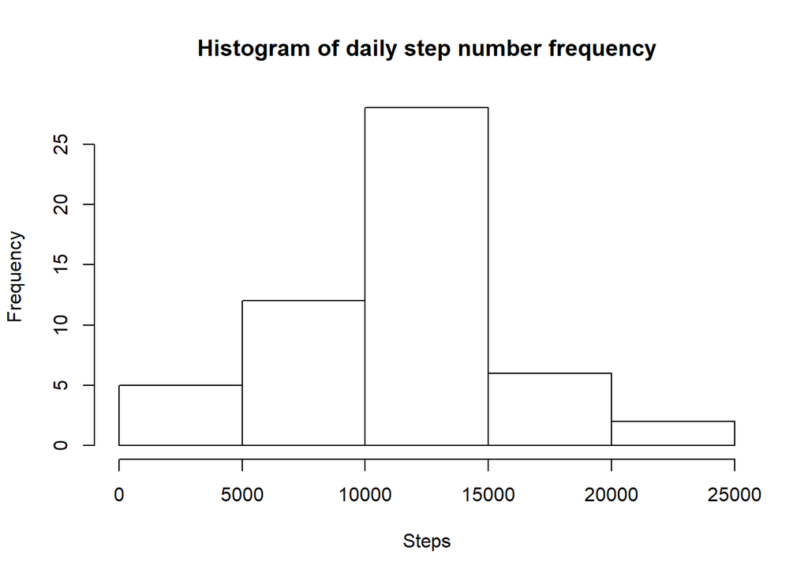

```r
hist(daily_df$steps,main ="Histogram of daily step number frequency", ylab="Frequency",xlab="Steps")
```

```r
daily_mean = mean(daily_df$steps)
```

```r
daily_median = median(daily_df$steps)
```

The daily median of steps taken is: 10765

## What is the average daily activity pattern?

### 1. Make a time series plot of the 5-minute interval (x-axis) and the average number of steps taken, averaged across all days (y-axis)

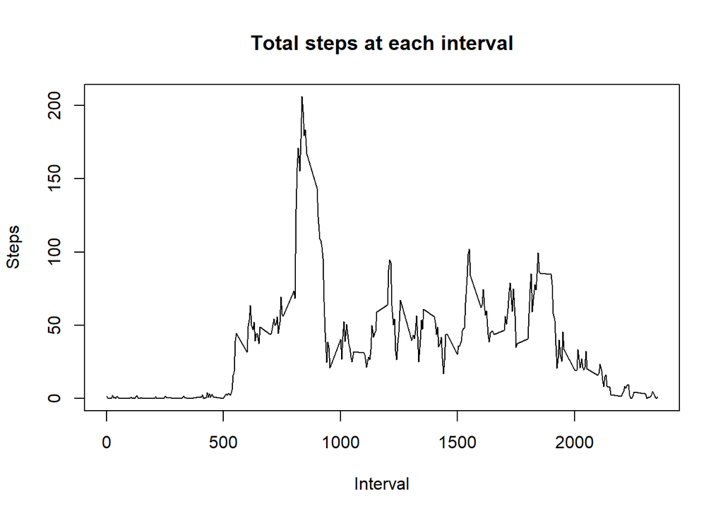

```r
interval_df = aggregate(steps ~ interval ,df,mean )
plot(interval_df$interval,interval_df$steps,main ="Total steps at each interval", ylab="Steps",xlab="Interval",type="l")
```

### 2. Which 5-minute interval, on average across all the days in the dataset, contains the maximum number of steps?

```r
max_steps_interval = interval_df$interval[interval_df$steps == max(interval_df$steps)]
```

The maximum number of steps is found in the interval 835

## Inputing missing values

NAs)

The number of missing values can be obtained in the following way:

```r
na_total = sum(is.na(df$steps))
```

### 2. Devise a strategy for filling in all of the missing values in the dataset. The strategy does not need to be sophisticated. For example, you could use the mean/median for that day, or the mean for that 5-minute interval, etc.

In this assignment I propose to replace the missing values with the corresponding step average for that particular interval truncated to its floor.

```r
new_df=df

for( i in c(1:length(df$steps))) {

       if(is.na(df$steps[i])) {

               new_df$steps[i]=floor(interval_df$steps[interval_df$interval == df$interval[i]])
       }
}

new_daily_df = aggregate(steps ~ date,new_df,sum )
```

### 3. Make a histogram of the total number of steps taken each day with replaced NAs

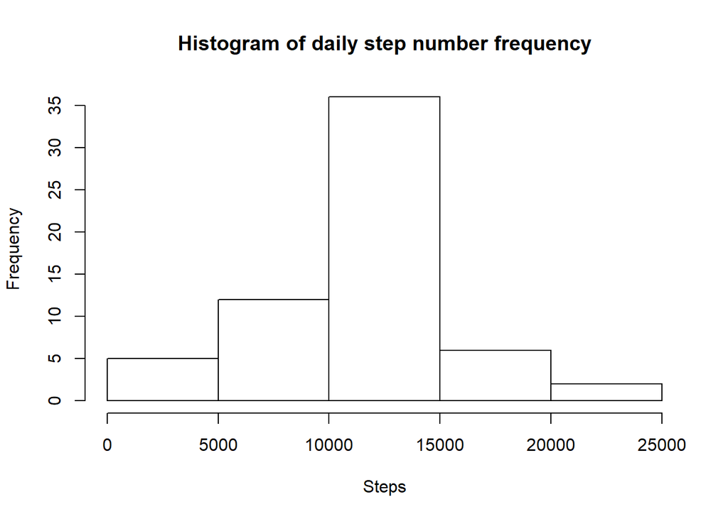

```r
hist(new_daily_df$steps,main ="Histogram of daily step number frequency", ylab="Frequency",xlab="Steps")
```

```r
new_daily_mean = mean(new_daily_df$steps)
```

```r
new_daily_median = median(new_daily_df$steps)
```

## Are there differences in activity patterns between weekdays and weekends?

### 1. Create a new factor variable in the dataset with two levels - “weekday” and “weekend” indicating whether a given date is a weekday or weekend day.

```r
cday = weekdays(as.Date(new_df$date))
weekday = cday

for( i in c(1:length(cday))){

      weekday[i] = cday[i] == "Monday" || cday[i] == "Tuesday" ||
              cday[i] == "Wednesday" || cday[i] == "Thursday" ||
              cday[i] == "Friday"
}

df_weekday_factor_added = cbind(new_df,weekday)
```

### 2. Make a panel plot containing a time series plot of the 5-minute interval (x-axis) and the average number of steps taken, averaged across all weekday days or weekend days (y-axis).

First split the df into weekdays and weekends

```r
df_wd = new_df[df_weekday_factor_added$weekday==TRUE,]
df_nwd = new_df[df_weekday_factor_added$weekday==FALSE,]
```

Calculate the average steps at each interval for weekdays and weekends

```r
interval_wd_df = aggregate(steps ~ interval ,df_wd,mean )
interval_nwd_df = aggregate(steps ~ interval ,df_nwd,mean )
```

The plot can be found below:

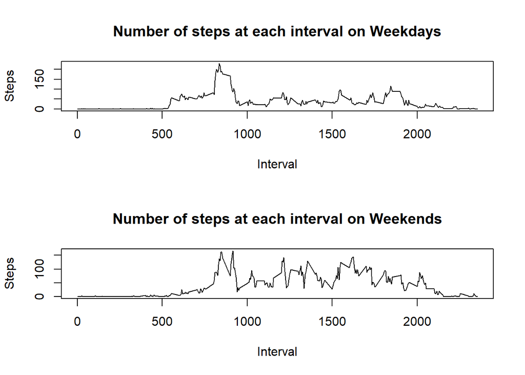

```r
par(mfrow=c(2,1))
plot(interval_nwd_df$interval,interval_wd_df$steps,main ="Number of steps at each interval on Weekdays", ylab="Steps",xlab="Interval", type="l")
plot(interval_wd_df$interval,interval_nwd_df$steps,main ="Number of steps at each interval on Weekends", ylab="Steps",xlab="Interval", type="l")
```